# UC00141_Building_Safety_Monitoring_Assistant

**Authored by:** Panha  
**Level:** Intermediate  
**Pre-requisite Skills:** Python, Pandas, Data Visualisation, Basic Machine Learning

### **Objective:**

This use case demonstrates how a building safety monitoring assistant can combine structural sensor readings and inspection notes to identify possible safety risks earlier. The notebook uses a small simulated dataset to show how vibration, tilt, crack width, temperature, humidity, and inspection text can be processed into a simple risk assessment.

The study focuses on:

- Exploring structural monitoring data
- Detecting unusual sensor behaviour using anomaly detection
- Analysing inspection report text for safety-related warning signs
- Producing clear risk levels and maintenance recommendations

### **Scenario:**

Building managers, engineers, and safety teams often need to monitor structures such as buildings, bridges, or public facilities. Manual inspections are useful, but they may not always detect fast-changing issues between inspection periods.

By combining sensor data with inspection notes, this use case shows how a simple Python workflow can:

- Highlight readings that may need closer attention
- Connect physical measurements with written inspection observations
- Support earlier maintenance decisions
- Communicate risk levels in a way that is understandable to non-technical audiences

### **What You Will Learn from This Use Case:**

1. Create and inspect a structural monitoring dataset
2. Visualise sensor behaviour over time
3. Apply anomaly detection to identify unusual readings
4. Score risk using sensor thresholds and inspection text
5. Generate simple maintenance recommendations from risk levels

### **Initial Setup and Data Loading**

In this section, we import the core Python libraries needed for the analysis:

- **Pandas and NumPy** → data handling and numerical processing
- **Matplotlib** → visualising sensor patterns over time
- **scikit-learn** → scaling data and detecting anomalies

The dataset used in this notebook is simulated for demonstration purposes. This makes the use case easy to run and understand without needing access to a live building monitoring system.

```python
# Import required libraries

import pandas as pd
import numpy as np
import matplotlib.pyplot as plt

from sklearn.ensemble import IsolationForest
from sklearn.preprocessing import StandardScaler

pd.set_option("display.max_colwidth", 120)
```

## Create or Load Sensor Dataset

For this prototype, a simulated dataset is used. This is acceptable for demonstrating the system logic because the project focuses on the technical pipeline.

In a real deployment, the same code could be connected to live IoT sensors or public structural health monitoring datasets.

```python
# Create a sample structural monitoring dataset

rng = np.random.default_rng(42)
timestamps = pd.date_range("2026-05-01 08:00", periods=160, freq="15min")

# Normal sensor behaviour
vibration = rng.normal(1.2, 0.25, len(timestamps))      # mm/s
tilt = rng.normal(0.08, 0.03, len(timestamps))          # degrees
crack_width = rng.normal(0.18, 0.04, len(timestamps))   # mm
temperature = rng.normal(21, 2, len(timestamps))        # Celsius
humidity = rng.normal(55, 6, len(timestamps))           # percentage

# Inject unusual behaviour to simulate safety risks
anomaly_idx_1 = np.arange(55, 68)
anomaly_idx_2 = np.arange(118, 128)

vibration[anomaly_idx_1] += rng.normal(2.8, 0.35, len(anomaly_idx_1))
tilt[anomaly_idx_1] += rng.normal(0.18, 0.04, len(anomaly_idx_1))

crack_width[anomaly_idx_2] += rng.normal(0.35, 0.06, len(anomaly_idx_2))
vibration[anomaly_idx_2] += rng.normal(1.5, 0.25, len(anomaly_idx_2))

# Simulated inspection report notes
reports = []
for i in range(len(timestamps)):
    if i in anomaly_idx_1:
        reports.append("Increased vibration observed near support beam. Possible fatigue or loose connection.")
    elif i in anomaly_idx_2:
        reports.append("Visible crack widening and minor spalling near concrete column. Further inspection recommended.")
    elif i % 37 == 0:
        reports.append("Minor corrosion stains noted, no immediate movement detected.")
    else:
        reports.append("Routine inspection: no major structural issues observed.")

df = pd.DataFrame({
    "timestamp": timestamps,
    "vibration_mm_s": vibration.round(3),
    "tilt_degree": tilt.round(3),
    "crack_width_mm": crack_width.round(3),
    "temperature_c": temperature.round(2),
    "humidity_pct": humidity.round(2),
    "inspection_report": reports
})

df.head()
```

|  | timestamp | vibration_mm_s | tilt_degree | crack_width_mm | temperature_c | humidity_pct | inspection_report |
| --- | --- | --- | --- | --- | --- | --- | --- |
| 0 | 2026-05-01 08:00:00 | 1.276 | 0.051 | 0.211 | 21.45 | 46.03 | Minor corrosion stains noted, no immediate movement detected. |
| 1 | 2026-05-01 08:15:00 | 0.940 | 0.058 | 0.172 | 23.87 | 59.20 | Routine inspection: no major structural issues observed. |
| 2 | 2026-05-01 08:30:00 | 1.388 | 0.144 | 0.227 | 21.18 | 67.32 | Routine inspection: no major structural issues observed. |
| 3 | 2026-05-01 08:45:00 | 1.435 | 0.055 | 0.210 | 22.16 | 56.03 | Routine inspection: no major structural issues observed. |
| 4 | 2026-05-01 09:00:00 | 0.712 | 0.105 | 0.253 | 20.89 | 52.98 | Routine inspection: no major structural issues observed. |

## Explore the Dataset

Before modelling, inspect the dataset to understand the sensor ranges and check for missing values.

```python
print("Dataset shape:", df.shape)
print("\nMissing values:")
print(df.isna().sum())

df.describe()   # or df.describe(include=[np.number])
```

```
Dataset shape: (160, 7)

Missing values:
timestamp            0
vibration_mm_s       0
tilt_degree          0
crack_width_mm       0
temperature_c        0
humidity_pct         0
inspection_report    0
dtype: int64
```

|  | timestamp | vibration_mm_s | tilt_degree | crack_width_mm | temperature_c | humidity_pct |
| --- | --- | --- | --- | --- | --- | --- |
| count | 160 | 160.000000 | 160.000000 | 160.000000 | 160.000000 | 160.000000 |
| mean | 2026-05-02 03:52:30 | 1.514612 | 0.093825 | 0.201125 | 20.815125 | 54.868187 |
| min | 2026-05-01 08:00:00 | 0.667000 | 0.003000 | 0.087000 | 15.070000 | 39.610000 |
| 25% | 2026-05-01 17:56:15 | 1.071000 | 0.060000 | 0.155250 | 19.437500 | 49.977500 |
| 50% | 2026-05-02 03:52:30 | 1.232500 | 0.081500 | 0.187500 | 20.830000 | 55.070000 |
| 75% | 2026-05-02 13:48:45 | 1.398000 | 0.107250 | 0.213250 | 22.085000 | 59.132500 |
| max | 2026-05-02 23:45:00 | 4.693000 | 0.317000 | 0.677000 | 26.100000 | 69.300000 |
| std | NaN | 0.882502 | 0.056954 | 0.092890 | 2.037104 | 6.115749 |

## Visualise Sensor Behaviour

These graphs help show where unusual structural behaviour appears and make abnormal readings easier to identify.

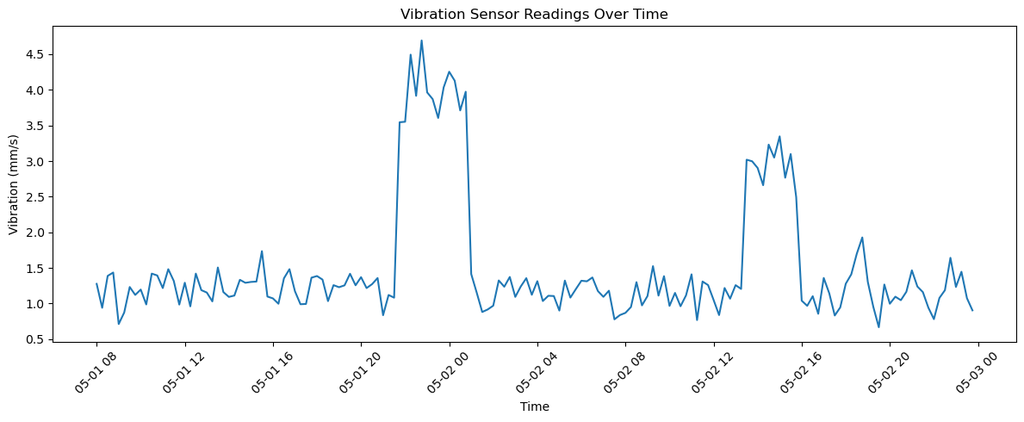

```python
plt.figure(figsize=(12, 5))
plt.plot(df["timestamp"], df["vibration_mm_s"])
plt.xlabel("Time")
plt.ylabel("Vibration (mm/s)")
plt.title("Vibration Sensor Readings Over Time")
plt.xticks(rotation=45)
plt.tight_layout()
plt.show()
```

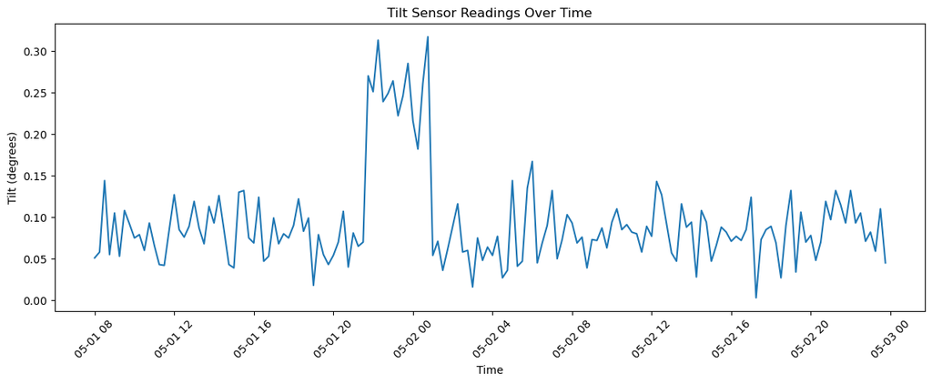

```python
plt.figure(figsize=(12, 5))
plt.plot(df["timestamp"], df["tilt_degree"])
plt.xlabel("Time")
plt.ylabel("Tilt (degrees)")
plt.title("Tilt Sensor Readings Over Time")
plt.xticks(rotation=45)
plt.tight_layout()
plt.show()
```

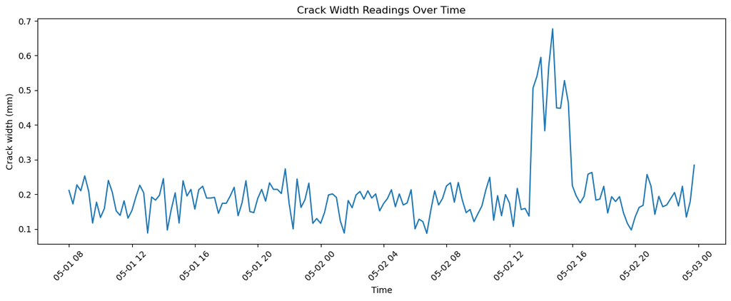

```python
plt.figure(figsize=(12, 5))
plt.plot(df["timestamp"], df["crack_width_mm"])
plt.xlabel("Time")
plt.ylabel("Crack width (mm)")
plt.title("Crack Width Readings Over Time")
plt.xticks(rotation=45)
plt.tight_layout()
plt.show()
```

## Detect Sensor Anomalies

The prototype uses **Isolation Forest**, an unsupervised anomaly detection method. This is suitable because real safety-monitoring systems may not always have labelled examples of every possible structural problem.

The model learns the normal pattern of the sensor readings and marks unusual points as anomalies.

```python
sensor_features = [
    "vibration_mm_s",
    "tilt_degree",
    "crack_width_mm",
    "temperature_c",
    "humidity_pct"
]

X = df[sensor_features]

# Scale features so that one unit does not dominate the model
scaler = StandardScaler()
X_scaled = scaler.fit_transform(X)

# Train anomaly detector
model = IsolationForest(
    n_estimators=150,
    contamination=0.08,
    random_state=42
)

df["anomaly_label"] = model.fit_predict(X_scaled)
df["is_anomaly"] = df["anomaly_label"].map({1: 0, -1: 1})
df["anomaly_score"] = -model.decision_function(X_scaled)

df[["timestamp", "vibration_mm_s", "tilt_degree", "crack_width_mm", "is_anomaly", "anomaly_score"]].head()
```

|  | timestamp | vibration_mm_s | tilt_degree | crack_width_mm | is_anomaly | anomaly_score |
| --- | --- | --- | --- | --- | --- | --- |
| 0 | 2026-05-01 08:00:00 | 1.276 | 0.051 | 0.211 | 0 | -0.160560 |
| 1 | 2026-05-01 08:15:00 | 0.940 | 0.058 | 0.172 | 0 | -0.153880 |
| 2 | 2026-05-01 08:30:00 | 1.388 | 0.144 | 0.227 | 0 | -0.070551 |
| 3 | 2026-05-01 08:45:00 | 1.435 | 0.055 | 0.210 | 0 | -0.187918 |
| 4 | 2026-05-01 09:00:00 | 0.712 | 0.105 | 0.253 | 0 | -0.101279 |

```python
# Show detected anomalies
anomalies = df[df["is_anomaly"] == 1]
anomalies[["timestamp", "vibration_mm_s", "tilt_degree", "crack_width_mm", "inspection_report"]].head(15)
```

|  | timestamp | vibration_mm_s | tilt_degree | crack_width_mm | inspection_report |
| --- | --- | --- | --- | --- | --- |
| 55 | 2026-05-01 21:45:00 | 3.545 | 0.270 | 0.273 | Increased vibration observed near support beam. Possible fatigue or loose connection. |
| 56 | 2026-05-01 22:00:00 | 3.552 | 0.251 | 0.172 | Increased vibration observed near support beam. Possible fatigue or loose connection. |
| 57 | 2026-05-01 22:15:00 | 4.494 | 0.313 | 0.100 | Increased vibration observed near support beam. Possible fatigue or loose connection. |
| 58 | 2026-05-01 22:30:00 | 3.916 | 0.239 | 0.244 | Increased vibration observed near support beam. Possible fatigue or loose connection. |
| 59 | 2026-05-01 22:45:00 | 4.693 | 0.249 | 0.162 | Increased vibration observed near support beam. Possible fatigue or loose connection. |
| 60 | 2026-05-01 23:00:00 | 3.964 | 0.264 | 0.184 | Increased vibration observed near support beam. Possible fatigue or loose connection. |
| 67 | 2026-05-02 00:45:00 | 3.973 | 0.317 | 0.201 | Increased vibration observed near support beam. Possible fatigue or loose connection. |
| 113 | 2026-05-02 12:15:00 | 0.838 | 0.143 | 0.107 | Routine inspection: no major structural issues observed. |
| 119 | 2026-05-02 13:45:00 | 2.997 | 0.088 | 0.540 | Visible crack widening and minor spalling near concrete column. Further inspection recommended. |
| 120 | 2026-05-02 14:00:00 | 2.903 | 0.094 | 0.595 | Visible crack widening and minor spalling near concrete column. Further inspection recommended. |
| 122 | 2026-05-02 14:30:00 | 3.231 | 0.108 | 0.568 | Visible crack widening and minor spalling near concrete column. Further inspection recommended. |
| 123 | 2026-05-02 14:45:00 | 3.049 | 0.094 | 0.677 | Visible crack widening and minor spalling near concrete column. Further inspection recommended. |
| 125 | 2026-05-02 15:15:00 | 2.766 | 0.066 | 0.448 | Visible crack widening and minor spalling near concrete column. Further inspection recommended. |

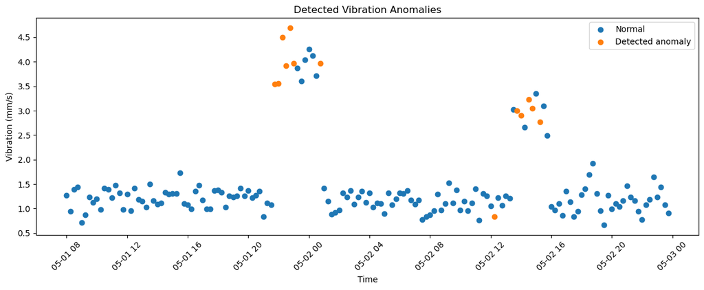

```python
plt.figure(figsize=(12, 5))

normal = df[df["is_anomaly"] == 0]
anomaly = df[df["is_anomaly"] == 1]

plt.scatter(normal["timestamp"], normal["vibration_mm_s"], label="Normal")
plt.scatter(anomaly["timestamp"], anomaly["vibration_mm_s"], label="Detected anomaly")

plt.xlabel("Time")
plt.ylabel("Vibration (mm/s)")
plt.title("Detected Vibration Anomalies")
plt.xticks(rotation=45)
plt.legend()
plt.tight_layout()
plt.show()
```

## Analyse Inspection Report Text

A clear keyword-based text analysis method is used for this public demonstration.

The system searches for engineering risk terms such as crack, corrosion, fatigue, spalling, settlement, and water ingress. This makes the system explainable during the demonstration.

```python
risk_keywords = {
    "crack": 2,
    "cracking": 2,
    "widening": 2,
    "fatigue": 3,
    "corrosion": 2,
    "spalling": 2,
    "settlement": 3,
    "movement": 2,
    "loose connection": 2,
    "water ingress": 2,
    "deformation": 3
}

def text_risk_score(report):
    report_lower = report.lower()
    score = 0

    for keyword, weight in risk_keywords.items():
        if keyword in report_lower:
            score += weight

    return score

df["text_risk_score"] = df["inspection_report"].apply(text_risk_score)

df[["inspection_report", "text_risk_score"]].drop_duplicates().head(10)
```

|  | inspection_report | text_risk_score |
| --- | --- | --- |
| 0 | Minor corrosion stains noted, no immediate movement detected. | 4 |
| 1 | Routine inspection: no major structural issues observed. | 0 |
| 55 | Increased vibration observed near support beam. Possible fatigue or loose connection. | 5 |
| 118 | Visible crack widening and minor spalling near concrete column. Further inspection recommended. | 6 |

## Generate Risk Assessment

The final risk score combines:

1. Sensor threshold score
2. Machine-learning anomaly result
3. Inspection report text risk score

This makes the assistant more useful than a simple graph because it converts raw data into a decision-support output.

```python
def sensor_threshold_score(row):
    score = 0

    # These are simple demonstration thresholds.
    # In a real system, thresholds should come from engineering standards or expert advice.
    if row["vibration_mm_s"] > 3.0:
        score += 3
    elif row["vibration_mm_s"] > 2.0:
        score += 2
    elif row["vibration_mm_s"] > 1.5:
        score += 1

    if row["tilt_degree"] > 0.25:
        score += 3
    elif row["tilt_degree"] > 0.15:
        score += 2
    elif row["tilt_degree"] > 0.10:
        score += 1

    if row["crack_width_mm"] > 0.50:
        score += 3
    elif row["crack_width_mm"] > 0.35:
        score += 2
    elif row["crack_width_mm"] > 0.25:
        score += 1

    return score

def classify_risk(total_score):
    if total_score >= 8:
        return "High"
    elif total_score >= 4:
        return "Medium"
    else:
        return "Low"

df["sensor_threshold_score"] = df.apply(sensor_threshold_score, axis=1)

# Combine evidence into one explainable risk score
df["final_risk_score"] = (
    df["sensor_threshold_score"]
    + (df["is_anomaly"] * 3)
    + df["text_risk_score"]
)

df["risk_level"] = df["final_risk_score"].apply(classify_risk)

df[[
    "timestamp",
    "vibration_mm_s",
    "tilt_degree",
    "crack_width_mm",
    "sensor_threshold_score",
    "is_anomaly",
    "text_risk_score",
    "final_risk_score",
    "risk_level"
]].head()
```

|  | timestamp | vibration_mm_s | tilt_degree | crack_width_mm | sensor_threshold_score | is_anomaly | text_risk_score | final_risk_score | risk_level |
| --- | --- | --- | --- | --- | --- | --- | --- | --- | --- |
| 0 | 2026-05-01 08:00:00 | 1.276 | 0.051 | 0.211 | 0 | 0 | 4 | 4 | Medium |
| 1 | 2026-05-01 08:15:00 | 0.940 | 0.058 | 0.172 | 0 | 0 | 0 | 0 | Low |
| 2 | 2026-05-01 08:30:00 | 1.388 | 0.144 | 0.227 | 1 | 0 | 0 | 1 | Low |
| 3 | 2026-05-01 08:45:00 | 1.435 | 0.055 | 0.210 | 0 | 0 | 0 | 0 | Low |
| 4 | 2026-05-01 09:00:00 | 0.712 | 0.105 | 0.253 | 2 | 0 | 0 | 2 | Low |

```python
df["risk_level"].value_counts()
```

```
risk_level
Low       131
High       23
Medium      6
Name: count, dtype: int64
```

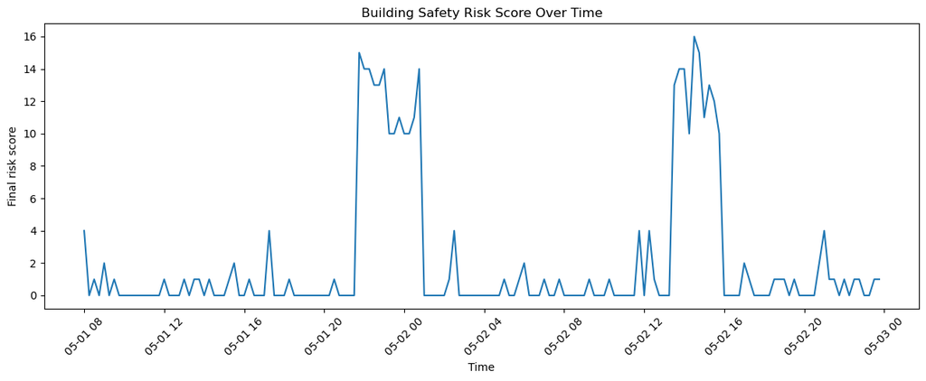

```python
plt.figure(figsize=(12, 5))
plt.plot(df["timestamp"], df["final_risk_score"])
plt.xlabel("Time")
plt.ylabel("Final risk score")
plt.title("Building Safety Risk Score Over Time")
plt.xticks(rotation=45)
plt.tight_layout()
plt.show()
```

## Recommend Maintenance Actions

The assistant now converts the risk level into a clear recommendation.

```python
def recommend_action(risk_level):
    if risk_level == "High":
        return "Urgent inspection within 24–48 hours. Increase monitoring and consider restricting access until checked."
    elif risk_level == "Medium":
        return "Schedule engineering inspection within 7 days and monitor the affected sensor readings more frequently."
    else:
        return "Continue routine monitoring and normal periodic inspection."

df["recommended_action"] = df["risk_level"].apply(recommend_action)

df[[
    "timestamp",
    "risk_level",
    "final_risk_score",
    "inspection_report",
    "recommended_action"
]].head(12)
```

|  | timestamp | risk_level | final_risk_score | inspection_report | recommended_action |
| --- | --- | --- | --- | --- | --- |
| 0 | 2026-05-01 08:00:00 | Medium | 4 | Minor corrosion stains noted, no immediate movement detected. | Schedule engineering inspection within 7 days and monitor the affected sensor readings more frequently. |
| 1 | 2026-05-01 08:15:00 | Low | 0 | Routine inspection: no major structural issues observed. | Continue routine monitoring and normal periodic inspection. |
| 2 | 2026-05-01 08:30:00 | Low | 1 | Routine inspection: no major structural issues observed. | Continue routine monitoring and normal periodic inspection. |
| 3 | 2026-05-01 08:45:00 | Low | 0 | Routine inspection: no major structural issues observed. | Continue routine monitoring and normal periodic inspection. |
| 4 | 2026-05-01 09:00:00 | Low | 2 | Routine inspection: no major structural issues observed. | Continue routine monitoring and normal periodic inspection. |
| 5 | 2026-05-01 09:15:00 | Low | 0 | Routine inspection: no major structural issues observed. | Continue routine monitoring and normal periodic inspection. |
| 6 | 2026-05-01 09:30:00 | Low | 1 | Routine inspection: no major structural issues observed. | Continue routine monitoring and normal periodic inspection. |
| 7 | 2026-05-01 09:45:00 | Low | 0 | Routine inspection: no major structural issues observed. | Continue routine monitoring and normal periodic inspection. |
| 8 | 2026-05-01 10:00:00 | Low | 0 | Routine inspection: no major structural issues observed. | Continue routine monitoring and normal periodic inspection. |
| 9 | 2026-05-01 10:15:00 | Low | 0 | Routine inspection: no major structural issues observed. | Continue routine monitoring and normal periodic inspection. |
| 10 | 2026-05-01 10:30:00 | Low | 0 | Routine inspection: no major structural issues observed. | Continue routine monitoring and normal periodic inspection. |
| 11 | 2026-05-01 10:45:00 | Low | 0 | Routine inspection: no major structural issues observed. | Continue routine monitoring and normal periodic inspection. |

```python
# Display the highest-risk cases

top_risks = df.sort_values("final_risk_score", ascending=False).head(10)

top_risks[[
    "timestamp",
    "vibration_mm_s",
    "tilt_degree",
    "crack_width_mm",
    "risk_level",
    "final_risk_score",
    "inspection_report",
    "recommended_action"
]]
```

|  | timestamp | vibration_mm_s | tilt_degree | crack_width_mm | risk_level | final_risk_score | inspection_report | recommended_action |
| --- | --- | --- | --- | --- | --- | --- | --- | --- |
| 122 | 2026-05-02 14:30:00 | 3.231 | 0.108 | 0.568 | High | 16 | Visible crack widening and minor spalling near concrete column. Further inspection recommended. | Urgent inspection within 24–48 hours. Increase monitoring and consider restricting access until checked. |
| 55 | 2026-05-01 21:45:00 | 3.545 | 0.270 | 0.273 | High | 15 | Increased vibration observed near support beam. Possible fatigue or loose connection. | Urgent inspection within 24–48 hours. Increase monitoring and consider restricting access until checked. |
| 123 | 2026-05-02 14:45:00 | 3.049 | 0.094 | 0.677 | High | 15 | Visible crack widening and minor spalling near concrete column. Further inspection recommended. | Urgent inspection within 24–48 hours. Increase monitoring and consider restricting access until checked. |
| 56 | 2026-05-01 22:00:00 | 3.552 | 0.251 | 0.172 | High | 14 | Increased vibration observed near support beam. Possible fatigue or loose connection. | Urgent inspection within 24–48 hours. Increase monitoring and consider restricting access until checked. |
| 57 | 2026-05-01 22:15:00 | 4.494 | 0.313 | 0.100 | High | 14 | Increased vibration observed near support beam. Possible fatigue or loose connection. | Urgent inspection within 24–48 hours. Increase monitoring and consider restricting access until checked. |
| 60 | 2026-05-01 23:00:00 | 3.964 | 0.264 | 0.184 | High | 14 | Increased vibration observed near support beam. Possible fatigue or loose connection. | Urgent inspection within 24–48 hours. Increase monitoring and consider restricting access until checked. |
| 67 | 2026-05-02 00:45:00 | 3.973 | 0.317 | 0.201 | High | 14 | Increased vibration observed near support beam. Possible fatigue or loose connection. | Urgent inspection within 24–48 hours. Increase monitoring and consider restricting access until checked. |
| 119 | 2026-05-02 13:45:00 | 2.997 | 0.088 | 0.540 | High | 14 | Visible crack widening and minor spalling near concrete column. Further inspection recommended. | Urgent inspection within 24–48 hours. Increase monitoring and consider restricting access until checked. |
| 120 | 2026-05-02 14:00:00 | 2.903 | 0.094 | 0.595 | High | 14 | Visible crack widening and minor spalling near concrete column. Further inspection recommended. | Urgent inspection within 24–48 hours. Increase monitoring and consider restricting access until checked. |
| 125 | 2026-05-02 15:15:00 | 2.766 | 0.066 | 0.448 | High | 13 | Visible crack widening and minor spalling near concrete column. Further inspection recommended. | Urgent inspection within 24–48 hours. Increase monitoring and consider restricting access until checked. |

## Simple Demo Function

This function allows a new sensor reading and inspection note to be tested immediately.

This is useful in the demonstration because you can type in a new example and show that the assistant produces a risk assessment.

```python
def analyse_new_reading(vibration_mm_s, tilt_degree, crack_width_mm, temperature_c, humidity_pct, inspection_report):
    new_data = pd.DataFrame([{
        "vibration_mm_s": vibration_mm_s,
        "tilt_degree": tilt_degree,
        "crack_width_mm": crack_width_mm,
        "temperature_c": temperature_c,
        "humidity_pct": humidity_pct
    }])

    new_scaled = scaler.transform(new_data[sensor_features])
    anomaly_prediction = model.predict(new_scaled)[0]
    is_anomaly = 1 if anomaly_prediction == -1 else 0

    temp_row = {
        "vibration_mm_s": vibration_mm_s,
        "tilt_degree": tilt_degree,
        "crack_width_mm": crack_width_mm
    }

    sensor_score = sensor_threshold_score(temp_row)
    text_score = text_risk_score(inspection_report)
    final_score = sensor_score + (is_anomaly * 3) + text_score
    risk_level = classify_risk(final_score)
    action = recommend_action(risk_level)

    result = {
        "vibration_mm_s": vibration_mm_s,
        "tilt_degree": tilt_degree,
        "crack_width_mm": crack_width_mm,
        "is_anomaly": is_anomaly,
        "text_risk_score": text_score,
        "final_risk_score": final_score,
        "risk_level": risk_level,
        "recommended_action": action
    }

    return pd.DataFrame([result])

analyse_new_reading(
    vibration_mm_s=4.2,
    tilt_degree=0.31,
    crack_width_mm=0.54,
    temperature_c=22.0,
    humidity_pct=58.0,
    inspection_report="Increased vibration and crack widening. Possible fatigue near support beam."
)
```

|  | vibration_mm_s | tilt_degree | crack_width_mm | is_anomaly | text_risk_score | final_risk_score | risk_level | recommended_action |
| --- | --- | --- | --- | --- | --- | --- | --- | --- |
| 0 | 4.2 | 0.31 | 0.54 | 1 | 7 | 19 | High | Urgent inspection within 24–48 hours. Increase monitoring and consider restricting access until checked. |